# Estimando Densidade Condicional

#### Felipe Maia Polo (felipemaiapolo@gmail.com)

Suponha um conjunto de dados $\mathcal{D}=\{(x_i,y_i)\}_{i=1}^n$ amostrado de forma independente de uma distribuição $P_{X,Y}$ com densidade $p_{X,Y}$. Nosso objetivo é estimar a densidade condicional $p_{Y|X}$ a partir do conjunto de dados $\mathcal{D}$. Suponha que $Y$ seja uma variável aleatória que assume valores em $\mathcal{Y}=[y_\text{min},y_\text{max}]$ com probabilidade 1, sendo que $\Delta y:=y_\text{max}-y_\text{min}$. Afim de continuarmos, considere a seguinte variável aleatória 'dummy' $\tilde{Y}\sim U[y_\text{min},y_\text{max}]$ independente de $(X,Y)$ e com f.d.p. dada por $p_\tilde{Y}(y)=\frac{1}{\Delta y}\mathbb{I}_\mathcal{Y}(y)$. Agora veja que podemos reescrever $p_{Y|X}$ da seguinte forma:

\begin{align} p_{Y|X}(y|x)&=\frac{p_{X,Y}(x,y)}{p_{X}(x)} \\[.5em] &=\frac{\Delta y}{\Delta y}\frac{p_{X,Y}(x,y)}{p_{X}(x)} \\[.5em] &=\frac{1}{\Delta y}\frac{1}{p_\tilde{Y}(y)}\frac{p_{X,Y}(x,y)}{p_{X}(x)} \\[.5em] &=\frac{1}{\Delta y}\frac{p_{X,Y}(x,y)}{p_{X,\tilde{Y}}(x,y)} \end{align}

Agora considere o vetor aleatório $(X',Y')\sim P_{X',Y'}$ com f.d.p. $p_{X',Y'}$ e uma variável aleatória $S \sim \text{Bernoulli}(1/2)$, sendo que $p_{X,Y}(x,y)=p_{X',Y'|S}(x,y|S=1)$ e $p_{X,\tilde{Y}}(x,y)=p_{X',Y'|S}(x,y|S=0)$. Ou seja, $S$ é uma variável que indica se uma amostra vem de $P_{X,Y}$ ou de $P_{X,\tilde{Y}}$. Logo:

\begin{align} p_{Y|X}(y|x)&=\frac{1}{\Delta y}\frac{p_{X',Y'|S}(x,y|S=1)}{p_{X',Y'|S}(x,y|S=0)} \\[.5em] &= \frac{1}{\Delta y}\frac{\mathbb{P}_{S|X',Y'}(S=1|x,y)}{\mathbb{P}_{S|X',Y'}(S=0|x,y)} \end{align}

A partir dos dados $\mathcal{D}$ criamos uma base de dados 'dummy' $\tilde{\mathcal{D}}=\{(x_i,\tilde{y}_i)\}_{i=1}^n$, com os pontos $(\tilde{y}_i)_i$ sendo realizações de $\tilde{Y}$. Criamos rótulos artificiais para as amostras de $\mathcal{D}$ e de $\mathcal{D}'$, sendo que o primeiro recebe rótulos 1 e o segundo recebe rótulos 0. O nosso estimador para a densidade condicional é dada da seguinte maneira

\begin{align} \widehat{p}_{Y|X}(y|x)&=\frac{1}{\Delta y}\frac{\widehat{\mathbb{P}}_{S|X',Y'}(S=1|x,y)}{\widehat{\mathbb{P}}_{S|X',Y'}(S=0|x,y)} \end{align}

Sendo que $\widehat{\mathbb{P}}$ representa um classificador probabilístico *não-linear* (regressão logística combinada com uma expansão das variáveis originais, XGBoost, Rede Neural MLP, etc). Em situações práticas podemos não conhececer os valores $y_\text{min},y_\text{max}$, mas podemos adotar $y_\text{min}=\text{min}\{y_i\}_{i=1}^n$ e $y_\text{max}=\text{max}\{y_i\}_{i=1}^n$ se não temos informações o suficiente a priori.

Importando pacotes:

```python
import random
import numpy as np
import matplotlib.pyplot as plt
from sklearn.preprocessing import PolynomialFeatures
from sklearn.linear_model import LogisticRegression
from sklearn.model_selection import GridSearchCV
```

Amostrando de $P_{X,Y}$:

```python
n=4000

x1=np.linspace(-6,6,int(n/2)) #np.random.normal(0,1,n) #
x2=np.linspace(-6,6,int(n/2))
y1=2*x1+np.random.normal(0,2,int(n/2))
y2=-2*x2+np.random.normal(0,2,int(n/2))

x=np.vstack((x1.reshape(-1,1),x2.reshape(-1,1))).squeeze()
y=np.vstack((y1.reshape(-1,1),y2.reshape(-1,1))).squeeze()
```

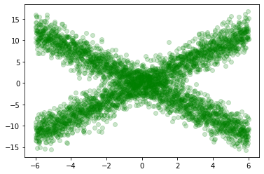

```python
plt.plot(x,y,'go', alpha=.2)
plt.show()
```

Amostrando de $P_{X,\tilde{Y}}$:

```python
y_min=np.min(y)
y_max=np.max(y)

y_dummy=np.random.uniform(y_min, y_max, n)
```

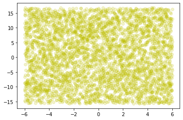

```python
plt.plot(x,y_dummy,'yo', alpha=.2)
plt.show()
```

Observando tudo no mesmo gráfico:

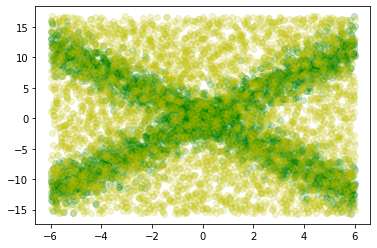

```python
plt.plot(x,y,'go', alpha=.2)
plt.plot(x,y_dummy,'yo', alpha=.2)
plt.show()
```

Criando os datasets $\mathcal{D}$ e $\mathcal{D}'$:

```python
D=np.vstack((x,y)).T
D_dummy=np.vstack((x,y_dummy)).T
```

Criando uma expansão polinomial das features, empilhando os datasets e criando os rótulos artificiais:

```python
poly = PolynomialFeatures(4)

aux_D=np.vstack((D_dummy,D))
aux_D=poly.fit_transform(aux_D)
aux_y=np.vstack((np.zeros(n).reshape(-1,1),np.ones(n).reshape(-1,1))).squeeze()
```

Treinando Regressão Logística:

```python
%%time
parameters = {'C': np.linspace(10**-5,10,50)}
model=LogisticRegression(penalty='l1',solver='liblinear')
cv = GridSearchCV(model, parameters, cv=3, n_jobs=-1)
cv.fit(aux_D,aux_y)
```

```
CPU times: user 1.14 s, sys: 145 ms, total: 1.29 s
Wall time: 1min 23s
```

```python
cv.best_params_, cv.best_score_
```

```
({'C': 9.795918571428572}, 0.4896327193909464)
```

```python
model=LogisticRegression(penalty='l1', C=cv.best_params_['C'], solver='liblinear')
model.fit(aux_D,aux_y)
```

```
LogisticRegression(C=9.795918571428572, class_weight=None, dual=False,
                   fit_intercept=True, intercept_scaling=1, l1_ratio=None,
                   max_iter=100, multi_class='auto', n_jobs=None, penalty='l1',
                   random_state=None, solver='liblinear', tol=0.0001, verbose=0,
                   warm_start=False)
```

Criando função para densidade condicional em $X$:

```python
def cde(x):
  delta_y=y_max-y_min
  z=np.vstack((np.array(100*[x]),np.linspace(y_min,y_max,100))).T
  z=poly.fit_transform(z)
  return model.predict_proba(z)[:,1]/(delta_y*model.predict_proba(z)[:,0])
```

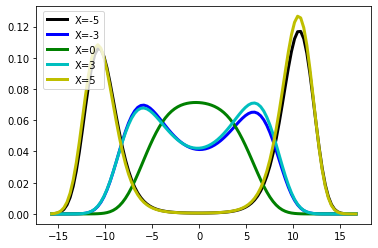

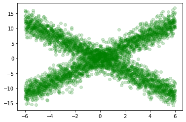

```python
cols={-5:'k',-3:'b' ,0:'g', 3:'c' ,5:'y'}

for X in [-5,-3,0,3,5]:
  plt.plot(np.linspace(y_min,y_max,100), cde(X), cols[X], lw=3, label='X='+str(X))
plt.legend(bbox_to_anchor=(.02, .98), loc='upper left', borderaxespad=.0)

plt.show()

plt.plot(x,y,'go',alpha=.2)
plt.show()
```